# Story Part 1

It’s a beautiful day. The sunrise is turning the sky fiery, birds are chirping, butterflies are fluttering, and fish are nibbling. Or rather, they would be if you weren’t using a net to fish.

You’ve decided that you want to make sushi for dinner tonight as a special treat and resolve to only use the freshest ingredients, including some fish that you’ve caught yourself. An over-zealous park ranger has made a map of your favorite pond that contains the location of each fish in the pond in **`polar form`**. Said ranger knows that computers prefer radians so he used those for the angle. Your puzzle input is the `list of every fish and its location in the pond`.

The list given to you looks like this, but longer:

```
Mackerel 2.236 4.249
Red Snapper 3.162 5.961
Sea Bass 0 3.142
Salmon 1 6.283
Sea Bass 3.606 5.695
```

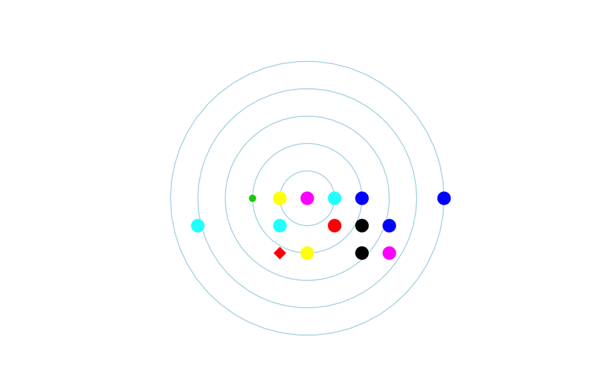

Your goal is to `find the polar coordinates` for the point in the pond where you can catch `at least three each Yellowfin Tuna, Salmon, and Mackerel, absolutely no Halibut or Walleye, and any number of other fish` with your net that has a `radius of five units`. Once you’ve found the proper magnitude and direction to the **`nearest thousandths`**, multiply them together for your passkey.